# dplyr practice worksheet - solutions

Jo Hardin

June 21, 2016

```r
require(babynames)
require(mosaic)
Babynames = babynames
```

Each year, the US Social Security Administration publishes a list of the most popular names given to babies. In 2014, [the list](http://www.ssa.gov/oact/babynames/#ht=2) shows Emma and Olivia leading for girls, Noah and Liam for boys.

The `babynames` data table in the `babynames` package comes from the Social Security Administration’s listing of the names givens to babies in each year, and the number of babies of each sex given that name. (Only names with 5 or more babies are published by the SSA.)

## Warm-ups

A few simple questions about the data.

When starting, it can be helpful to work with a small subset of the data. When you have your data wrangling statements in working order, shift to the entire data table.

```r
SmallSubset <-
  Babynames %>%
  filter(year > 2000) %>%
  sample_n(size = 200)
```

Note: Chunks in this template are headed with `{r eval=FALSE}`. Change this to `{r}` when you are ready to compile

### 1. How many babies are represented?

```r
SmallSubset %>%
  summarise(total = ????(n)) # a reduction verb
```

```r
SmallSubset %>%
  summarise(total=sum(n))
```

```
## Source: local data frame [1 x 1]
##
##   total
##   (int)
## 1 12601
```

### 2. How many babies are there in each year?

```r
SmallSubset %>%
  group_by(????) %>%
  summarise(total = ????(n))
```

```r
SmallSubset %>%
  group_by(year) %>%
  summarise(total = sum(n))
```

```
## Source: local data frame [14 x 2]
##
##     year total
##    (dbl) (int)
## 1   2001   826
## 2   2002   175
## 3   2003   640
## 4   2004   346
## 5   2005   770
## 6   2006   182
## 7   2007  1049
## 8   2008   495
## 9   2009   533
## 10  2010  1509
## 11  2011  4014
## 12  2012   769
## 13  2013  1004
## 14  2014   289
```

### 3. How many distinct names in each year?

```r
SmallSubset %>%
  group_by(????) %>%
  summarise(name_count = n_distinct(????))
```

```r
SmallSubset %>%
  group_by(year) %>%
  summarise(name_count = n_distinct(name))
```

```
## Source: local data frame [14 x 2]
##
##     year name_count
##    (dbl)      (int)
## 1   2001         17
## 2   2002          9
## 3   2003         13
## 4   2004         12
## 5   2005         19
## 6   2006         16
## 7   2007         10
## 8   2008         17
## 9   2009         19
## 10  2010          8
## 11  2011         15
## 12  2012         20
## 13  2013         13
## 14  2014         12
```

### 4. How many distinct names of each sex in each year?

```r
SmallSubset %>%
  group_by(????, ????) %>%
  summarise(????)
```

```r
SmallSubset %>%
  group_by(year, sex) %>%
  summarise(name_count=n_distinct(name))
```

```
## Source: local data frame [28 x 3]
## Groups: year [?]
##
##     year   sex name_count
##    (dbl) (chr)      (int)
## 1   2001     F          7
## 2   2001     M         10
## 3   2002     F          4
## 4   2002     M          5
## 5   2003     F          7
## 6   2003     M          6
## 7   2004     F          8
## 8   2004     M          4
## 9   2005     F         12
## 10  2005     M          7
## ..   ...   ...        ...
```

## Popularity of Jane and Mary

### 5. Track the yearly number of Janes and Marys over the years.

```r
Result <-
  Babynames %>%
  ????(name %in% c("Jane", "Mary")) %>% # just the Janes and Marys
  group_by(????, ????) %>% # for each year for each name
  summarise(count = ????)
```

```r
Result <-
  Babynames %>%
  filter(name %in% c("Jane", "Mary")) %>% # just the Janes and Marys
  group_by(name, year) %>% # for each year for each name
  summarise(count = sum(n))
```

### 6. Plot out the result

Put `year` on the x-axis and the count of each name on the y-axis. Note that `ggplot()` commands use `+` rather than `%>%`.

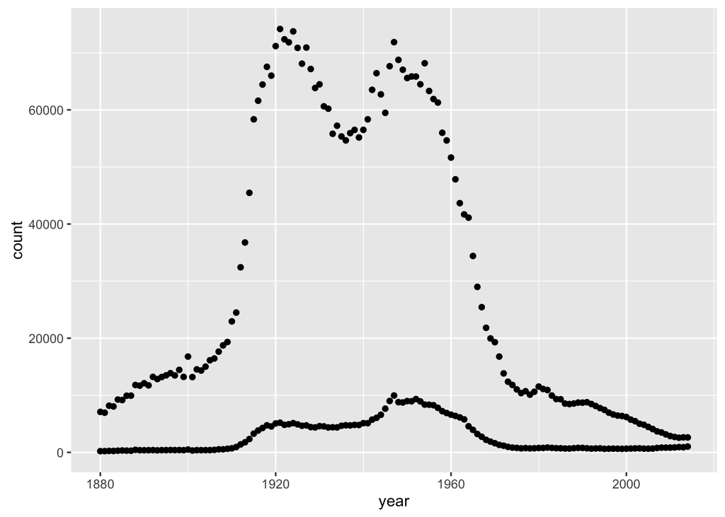

```r
ggplot(data=Result, aes(x = year, y = count)) +
  geom_point()
```

- *Map* the name (Mary or Jane) to the aesthetic of color. Remember that mapping to aesthetics is always done inside the `aes()` function.
- Instead of using dots as the glyph, use a line that connects consecutive values: `geom_line()`.
- Change the y-axis label to “Yearly Births”: `+ ylab("Yearly Births")`
- *Set* the line thickness to `size=2`. Remember that “setting” refers to adjusting the value of an aesthetic to a constant. Thus, it’s *outside* the `aes()` function.

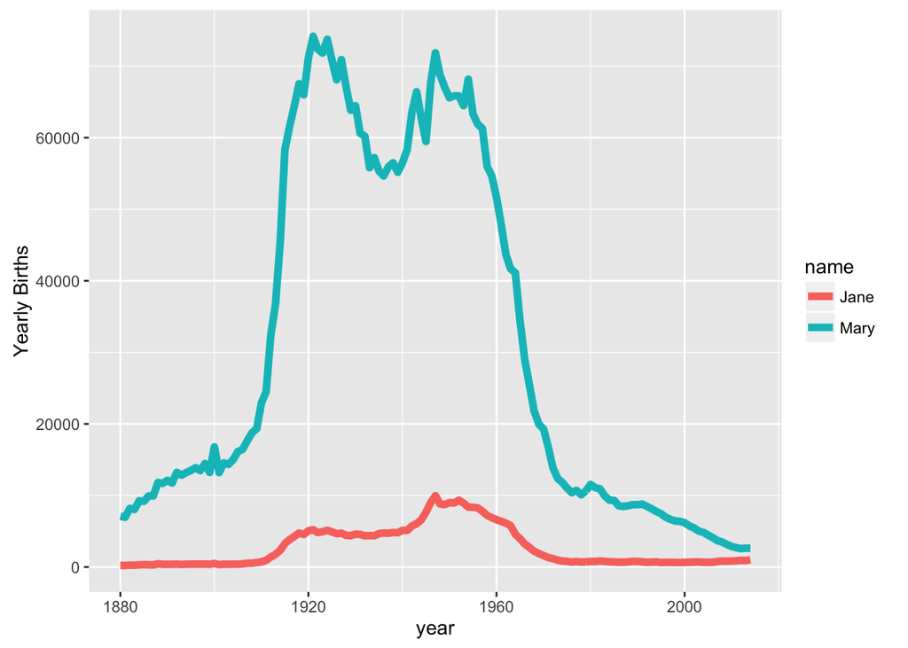

```r
ggplot(data=Result, aes(x = year, y = count)) +
  geom_line(aes(color=name), size=2) +
  ylab("Yearly Births")
```

### 7. Look at the *proportion* of births rather than the count

```r
Result2 <-
  Babynames %>%
  group_by(year) %>%
  mutate(total = ????(n)) %>%
  filter(????) %>%
  mutate(proportion = n / total)
```

```r
Result2 <-
  Babynames %>%
  group_by(year) %>%
  mutate(total = sum(n)) %>%
  filter(name %in% c("Mary", "Jane")) %>%
  mutate(proportion = n / total)
```

- Why is `sex` a variable in `Result2`? Eliminate it, keeping just the girls. Note: It would likely be better to add up the boys and girls, but this is surprisingly hard. It becomes much easier once you have another data verb to work with: `inner_join()`.
- What happens if the `filter()` step is put *before* the `mutate()` step?

```r
Result2 <-
  Babynames %>%
  filter(sex == "F") %>%
  group_by(year) %>%
  mutate(total = sum(n)) %>%
  filter(name %in% c("Mary", "Jane")) %>%
  mutate(proportion = n / total)
```

- Add a vertical line to mark a year in which something happened that might relate to the increase or decrease the popularity of the name. Example: The movie [*Whatever Happened to Baby Jane*](http://en.wikipedia.org/wiki/What_Ever_Happened_to_Baby_Jane%3F_%281962_film%29) came out in 1962. The glyph is a vertical line: `geom_vline()`.

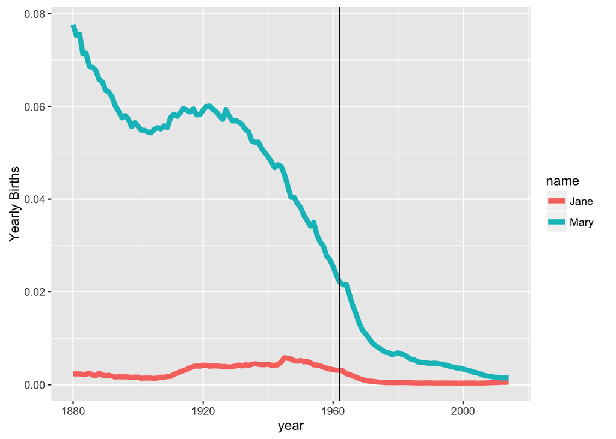

```r
ggplot(data=Result2, aes(x=year, y=proportion)) +
  geom_line(aes(color=name), size=2) +
  ylab("Yearly Births") +
  geom_vline(xintercept=1962)
```

## 8. Pick out name(s) of interest to you

Plot out their popularity over time.

# On to more data verbs (gather, join, lubridate)

## gather

```r
require(googlesheets)
require(tidyr)
```

gather the military paygrade data: https://docs.google.com/spreadsheets/d/1Ow6Cm4z-Z1Yybk3i352msulYCEDOUaOghmo9ALajyHo/edit#gid=1811988794

```r
navy.url = "https://docs.google.com/spreadsheets/d/1Ow6Cm4z-Z1Yybk3i352msulYCEDOUaOghmo9ALajyHo/edit#gid=1877566408"
navy.temp = gs_url(navy.url, visibility="public")
```

```
## Sheet-identifying info appears to be a browser URL.
## googlesheets will attempt to extract sheet key from the URL.
```

```
## Putative key: 1Ow6Cm4z-Z1Yybk3i352msulYCEDOUaOghmo9ALajyHo
```

```
## Worksheets feed constructed with public visibility
```

```r
Navy = gs_read(navy.temp)
```

```
## Accessing worksheet titled 'Navy'.
```

```
## No encoding supplied: defaulting to UTF-8.
```

```r
glimpse(Navy)
```

```
## Observations: 37
## Variables: 17
## $ X1                 (chr) NA, NA, NA, NA, NA, NA, NA, NA, NA, NA, NA,...
## $ Active Duty Family (chr) NA, "Marital Status Report", NA, "Data Refl...
## $ X3                 (chr) NA, NA, NA, NA, NA, NA, "Single Without Chi...
## $ X4                 (chr) NA, NA, NA, NA, NA, NA, NA, "Female", "2,27...
## $ X5                 (chr) NA, NA, NA, NA, NA, NA, NA, "Total", "10,09...
## $ X6                 (chr) NA, NA, NA, NA, NA, NA, "Single With Childr...
## $ X7                 (chr) NA, NA, NA, NA, NA, NA, NA, "Female", "34",...
## $ X8                 (chr) NA, NA, NA, NA, NA, NA, NA, "Total", "151",...
## $ X9                 (chr) NA, NA, NA, NA, NA, NA, "Joint Service Marr...
## $ X10                (chr) NA, NA, NA, NA, NA, NA, NA, "Female", "57",...
## $ X11                (chr) NA, NA, NA, NA, NA, NA, NA, "Total", "87", ...
## $ X12                (chr) NA, NA, NA, NA, NA, NA, "Civilian Marriage"...
## $ X13                (chr) NA, NA, NA, NA, NA, NA, NA, "Female", "162"...
## $ X14                (chr) NA, NA, NA, NA, NA, NA, NA, "Total", "968",...
## $ X15                (chr) NA, NA, NA, NA, NA, NA, "Total", "Male", "8...
## $ X16                (chr) NA, NA, NA, NA, NA, NA, NA, "Female", "2,52...
## $ X17                (chr) NA, NA, NA, NA, NA, NA, NA, "Total", "11,30...
```

```r
names(Navy) = c("X","pay.grade", "male.sing.wo", "female.sing.wo", "tot.sing.wo",
                "male.sing.w", "female.sing.w", "tot.sing.w", "male.joint.NA",
                "female.joint.NA", "tot.joint.NA", "male.civ.NA", "female.civ.NA",
                "tot.civ.NA", "male.tot.NA", "female.tot.NA", "tot.tot.NA")
Navy = Navy[-c(1:8), -1]

# get rid of total columns & rows:

NavyWR <-
  Navy %>%
  select(-contains("tot")) %>%
  filter(substr(pay.grade, 1, 5) != "TOTAL" & substr(pay.grade, 1, 5) != "GRAND" ) %>%
  gather(status,numPeople,-pay.grade) %>%
  separate(status, into=c("sex", "marital", "kids", sep=".")) %>%
  select(c(1:4,6)) %>% mutate(count=extract_numeric(numPeople))
NavyWR %>% head()
```

```
## Source: local data frame [6 x 6]
##
##   pay.grade   sex marital  kids numPeople count
##       <chr> <chr>   <chr> <chr>     <chr> <dbl>
## 1       E-1  male    sing    wo     7,820  7820
## 2       E-2  male    sing    wo    11,198 11198
## 3       E-3  male    sing    wo    28,163 28163
## 4       E-4  male    sing    wo    23,285 23285
## 5       E-5  male    sing    wo    18,856 18856
## 6       E-6  male    sing    wo     5,917  5917
```

Does a graph tell us if we did it right? what if we had done it wrong…?

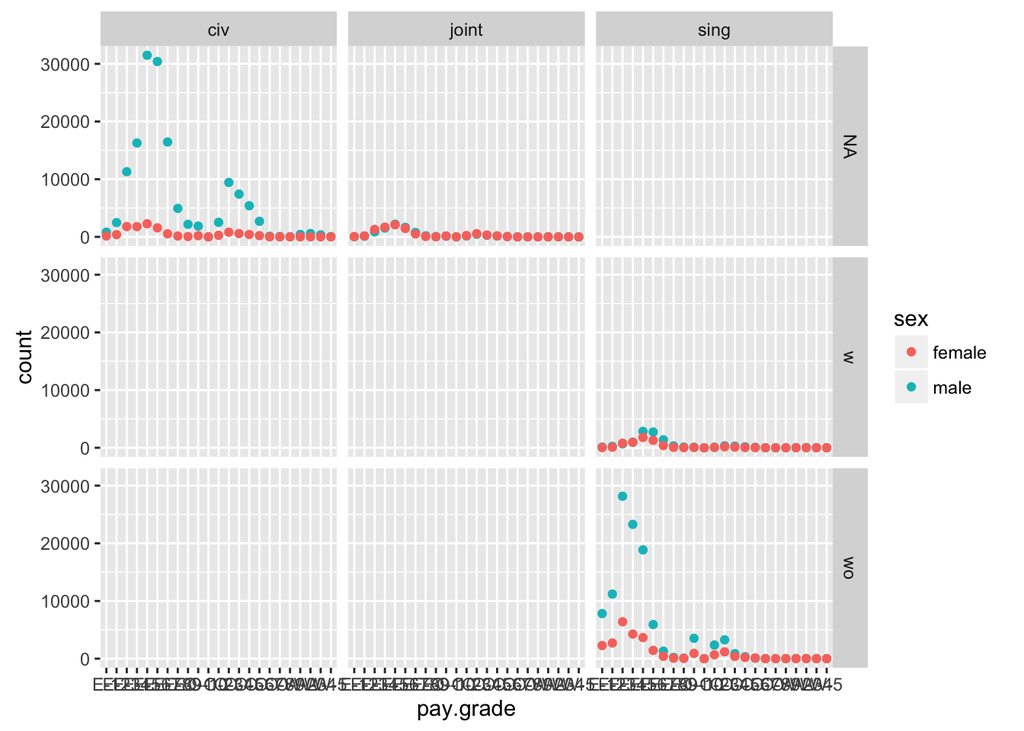

```r
NavyWR %>% ggplot(aes(x=pay.grade, y=count, color=sex)) +
  geom_point()  +
  facet_grid(kids~marital)
```

## join

The suite of *join* functions in dplyr allows for combining two different data tables by matching one or more variables. A great cheatsheet on joining: http://stat545.com/bit001_dplyr-cheatsheet.html

Using nycflights13: Airline on-time data for all flights departing NYC in 2013. Also includes useful ‘metadata’ on airlines, airports, weather, and planes.

```r
require(nycflights13)
Flights <- flights
Airports <- airports
Airlines <- airlines
Weather <- weather
Planes <- planes
```

```r
names(Flights)
```

```
##  [1] "year"           "month"          "day"            "dep_time"
##  [5] "sched_dep_time" "dep_delay"      "arr_time"       "sched_arr_time"
##  [9] "arr_delay"      "carrier"        "flight"         "tailnum"
## [13] "origin"         "dest"           "air_time"       "distance"
## [17] "hour"           "minute"         "time_hour"
```

```r
names(Airports)
```

```
## [1] "faa"  "name" "lat"  "lon"  "alt"  "tz"   "dst"
```

```r
names(Airlines)
```

```
## [1] "carrier" "name"
```

```r
names(Weather)
```

```
##  [1] "origin"     "year"       "month"      "day"        "hour"
##  [6] "temp"       "dewp"       "humid"      "wind_dir"   "wind_speed"
## [11] "wind_gust"  "precip"     "pressure"   "visib"      "time_hour"
```

```r
names(Planes)
```

```
## [1] "tailnum"      "year"         "type"         "manufacturer"
## [5] "model"        "engines"      "seats"        "speed"
## [9] "engine"
```

```r
Flights %>% select(carrier, flight, tailnum, origin, dest) %>% head()
```

```
## Source: local data frame [6 x 5]
##
##   carrier flight tailnum origin  dest
##     <chr>  <int>   <chr>  <chr> <chr>
## 1      UA   1545  N14228    EWR   IAH
## 2      UA   1714  N24211    LGA   IAH
## 3      AA   1141  N619AA    JFK   MIA
## 4      B6    725  N804JB    JFK   BQN
## 5      DL    461  N668DN    LGA   ATL
## 6      UA   1696  N39463    EWR   ORD
```

```r
Airports %>% select(faa, name, lat, lon) %>% head()
```

```
## Source: local data frame [6 x 4]
##
##     faa                           name      lat       lon
##   <chr>                          <chr>    <dbl>     <dbl>
## 1   04G              Lansdowne Airport 41.13047 -80.61958
## 2   06A  Moton Field Municipal Airport 32.46057 -85.68003
## 3   06C            Schaumburg Regional 41.98934 -88.10124
## 4   06N                Randall Airport 41.43191 -74.39156
## 5   09J          Jekyll Island Airport 31.07447 -81.42778
## 6   0A9 Elizabethton Municipal Airport 36.37122 -82.17342
```

```r
Airports %>% select(faa, name, lat, lon) %>% sample_n(5)
```

```
## Source: local data frame [5 x 4]
##
##     faa                                      name      lat       lon
##   <chr>                                     <chr>    <dbl>     <dbl>
## 1   GGW Wokal Field Glasgow International Airport 48.21250 -106.6150
## 2   KYU                           Koyukuk Airport 64.87583 -157.7306
## 3   CYS             Cheyenne Rgnl Jerry Olson Fld 41.15572 -104.8118
## 4   KPV                        Perryville Airport 55.90667 -159.1608
## 5   MCK                   McCook Regional Airport 40.20639 -100.5922
```

```r
Flights %>%
  inner_join(Airports, by=c("dest" = "faa")) %>%
  select(carrier, flight, tailnum, origin, dest, name, lat, lon) %>%
  head()
```

```
## Source: local data frame [6 x 8]
##
##   carrier flight tailnum origin  dest                            name
##     <chr>  <int>   <chr>  <chr> <chr>                           <chr>
## 1      UA   1545  N14228    EWR   IAH    George Bush Intercontinental
## 2      UA   1714  N24211    LGA   IAH    George Bush Intercontinental
## 3      AA   1141  N619AA    JFK   MIA                      Miami Intl
## 4      DL    461  N668DN    LGA   ATL Hartsfield Jackson Atlanta Intl
## 5      UA   1696  N39463    EWR   ORD              Chicago Ohare Intl
## 6      B6    507  N516JB    EWR   FLL  Fort Lauderdale Hollywood Intl
## Variables not shown: lat <dbl>, lon <dbl>.
```

```r
# inner_join: return all rows from x where there are matching values in y, and all columns from x and y.
Flights %>% inner_join(Airports, by=c("dest" = "faa")) %>% dim()
```

```
## [1] 329174     25
```

```r
# left_join: return all rows from x, and all columns from x and y.
Flights %>% left_join(Airports, by=c("dest" = "faa")) %>% dim()
```

```
## [1] 336776     25
```

```r
# right_join: return all rows from y, and all columns from x and y.
Flights %>% right_join(Airports, by=c("dest" = "faa")) %>% dim()
```

```
## [1] 330469     25
```

```r
# anti_join: return all rows from x where there are not matching values in y, keeping just columns from x.
Flights %>% anti_join(Airports, by=c("dest" = "faa")) %>% dim()
```

```
## [1] 7602   19
```

```r
# full_join: return all rows and all columns from both x and y.
Flights %>% full_join(Airports, by=c("dest" = "faa")) %>% dim()
```

```
## [1] 338071     25
```

## lubridate

Fun with dates!

```r
require(lubridate)

rightnow <- now()

day(rightnow)
```

```
## [1] 22
```

```r
week(rightnow)
```

```
## [1] 25
```

```r
month(rightnow, label=FALSE)
```

```
## [1] 6
```

```r
month(rightnow, label=TRUE)
```

```
## [1] Jun
## 12 Levels: Jan < Feb < Mar < Apr < May < Jun < Jul < Aug < Sep < ... < Dec
```

```r
year(rightnow)
```

```
## [1] 2016
```

```r
minute(rightnow)
```

```
## [1] 19
```

```r
hour(rightnow)
```

```
## [1] 7
```

```r
yday(rightnow)
```

```
## [1] 174
```

```r
mday(rightnow)
```

```
## [1] 22
```

```r
wday(rightnow, label=FALSE)
```

```
## [1] 4
```

```r
wday(rightnow, label=TRUE)
```

```
## [1] Wed
## Levels: Sun < Mon < Tues < Wed < Thurs < Fri < Sat
```

But how do I create a date object?

```r
jan31 <- ymd("2013-01-31")
jan31 + months(0:11)
```

```
##  [1] "2013-01-31" NA           "2013-03-31" NA           "2013-05-31"
##  [6] NA           "2013-07-31" "2013-08-31" NA           "2013-10-31"
## [11] NA           "2013-12-31"
```

```r
floor_date(jan31, "month") # round down to the nearest month
```

```
## [1] "2013-01-01"
```

```r
floor_date(jan31, "month") + months(0:11) + days(31)
```

```
##  [1] "2013-02-01" "2013-03-04" "2013-04-01" "2013-05-02" "2013-06-01"
##  [6] "2013-07-02" "2013-08-01" "2013-09-01" "2013-10-02" "2013-11-01"
## [11] "2013-12-02" "2014-01-01"
```

```r
jan31 + months(0:11) + days(31)
```

```
##  [1] "2013-03-03" NA           "2013-05-01" NA           "2013-07-01"
##  [6] NA           "2013-08-31" "2013-10-01" NA           "2013-12-01"
## [11] NA           "2014-01-31"
```

```r
jan31 %m+% months(0:11)
```

```
##  [1] "2013-01-31" "2013-02-28" "2013-03-31" "2013-04-30" "2013-05-31"
##  [6] "2013-06-30" "2013-07-31" "2013-08-31" "2013-09-30" "2013-10-31"
## [11] "2013-11-30" "2013-12-31"
```

```r
FlightsWK <-
  Flights %>%
  mutate(ymdday = ymd(paste(year,"-", month,"-",day))) %>%
  mutate(weekdy = wday(ymdday, label=TRUE), whichweek = week(ymdday))
FlightsWK %>%
  select(year, month, day, ymdday, weekdy, whichweek, dep_time,
                     arr_time, air_time) %>%
  head()
```

```
## Source: local data frame [6 x 9]
##
##    year month   day     ymdday weekdy whichweek dep_time arr_time air_time
##   <int> <int> <int>     <date> <fctr>     <dbl>    <int>    <int>    <dbl>
## 1  2013     1     1 2013-01-01   Tues         1      517      830      227
## 2  2013     1     1 2013-01-01   Tues         1      533      850      227
## 3  2013     1     1 2013-01-01   Tues         1      542      923      160
## 4  2013     1     1 2013-01-01   Tues         1      544     1004      183
## 5  2013     1     1 2013-01-01   Tues         1      554      812      116
## 6  2013     1     1 2013-01-01   Tues         1      554      740      150
```

### 9. More example problems to work out

(Many of these problems were taken from **Modern Data Science with R** by Baumer, Kaplan, and Horton, in preparation.)

- What plane (specified by the *tailnum* variable) traveled the most times from New York City airports in 2013? Plot the number of trips per week over the year (for that plane).

```r
tripsTot <- flights %>%
  group_by(tailnum) %>%
  summarize(numFl = n())
head(tripsTot)
```

```
## Source: local data frame [6 x 2]
##
##   tailnum numFl
##     <chr> <int>
## 1  D942DN     4
## 2  N0EGMQ   371
## 3  N10156   153
## 4  N102UW    48
## 5  N103US    46
## 6  N104UW    47
```

```r
flights %>%
  group_by(tailnum) %>%
  summarize(numFl = n()) %>%
  arrange(desc(numFl))
```

```
## Source: local data frame [4,044 x 2]
##
##    tailnum numFl
##      <chr> <int>
## 1       NA  2512
## 2   N725MQ   575
## 3   N722MQ   513
## 4   N723MQ   507
## 5   N711MQ   486
## 6   N713MQ   483
## 7   N258JB   427
## 8   N298JB   407
## 9   N353JB   404
## 10  N351JB   402
## ..     ...   ...
```

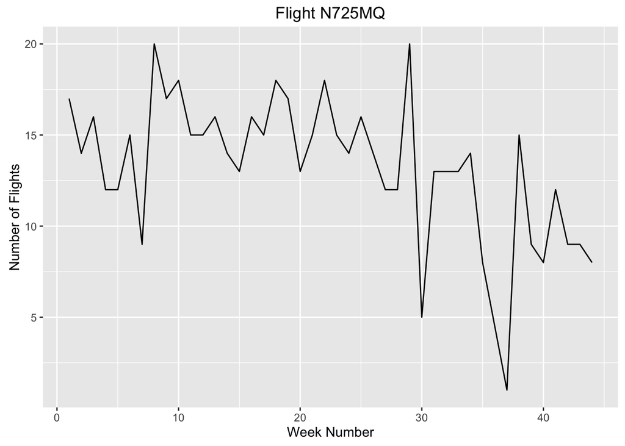

```r
#first find the week number for each flight
flights = flights %>%
  mutate(day.ymd = paste(year,"-", month,"-",day)) %>%
  mutate(week.n = week(ymd(day.ymd)))
plane.N725MQ <-
  flights %>%
  filter(tailnum=="N725MQ") %>%
  group_by(week.n) %>%
  summarize(numFlWk = n())

ggplot(plane.N725MQ, aes(x=week.n, y=numFlWk)) +
  geom_line() +
  xlab("Week Number") +
  ylab("Number of Flights") +
  ggtitle("Flight N725MQ")
```

- Use the *nycflights13* package and the *flights* and *planes* tables to answer the following questions:
  - What is the oldest plane (specified by the tailnum variable) that flew from New York City airports in 2013?

```r
planes %>% arrange(year)
```

```
## Source: local data frame [3,322 x 9]
##
##    tailnum  year                     type manufacturer       model engines
##      <chr> <int>                    <chr>        <chr>       <chr>   <int>
## 1   N381AA  1956  Fixed wing multi engine      DOUGLAS      DC-7BF       4
## 2   N201AA  1959 Fixed wing single engine       CESSNA         150       1
## 3   N567AA  1959 Fixed wing single engine  DEHAVILLAND OTTER DHC-3       1
## 4   N378AA  1963 Fixed wing single engine       CESSNA        172E       1
## 5   N575AA  1963 Fixed wing single engine       CESSNA  210-5(205)       1
## 6   N14629  1965  Fixed wing multi engine       BOEING     737-524       2
## 7   N615AA  1967  Fixed wing multi engine        BEECH      65-A90       2
## 8   N425AA  1968 Fixed wing single engine        PIPER   PA-28-180       1
## 9   N383AA  1972  Fixed wing multi engine        BEECH        E-90       2
## 10  N364AA  1973  Fixed wing multi engine       CESSNA        310Q       2
## ..     ...   ...                      ...          ...         ...     ...
## Variables not shown: seats <int>, speed <int>, engine <chr>.
```

```
+ How many airplanes (that flew from New York City) are included in the planes table? How many have missing date of manufacture?
```

```r
planes %>% summarize(n())  # 3322
```

```
## Source: local data frame [1 x 1]
##
##     n()
##   <int>
## 1  3322
```

```r
flights %>% group_by(tailnum) %>%
  left_join(planes, by="tailnum") %>%
  filter(is.na(manufacturer)) %>%
  summarize(n())  %>% dim() # 722
```

```
## [1] 722   2
```

```r
# note: none of the planes in the planes table have missing data, but 722 of the planes in the flights
# dataset are missing the manufacturer information from the planes dataset
```

```
+ Display and interpret the distribution of the date of manufacture.
```

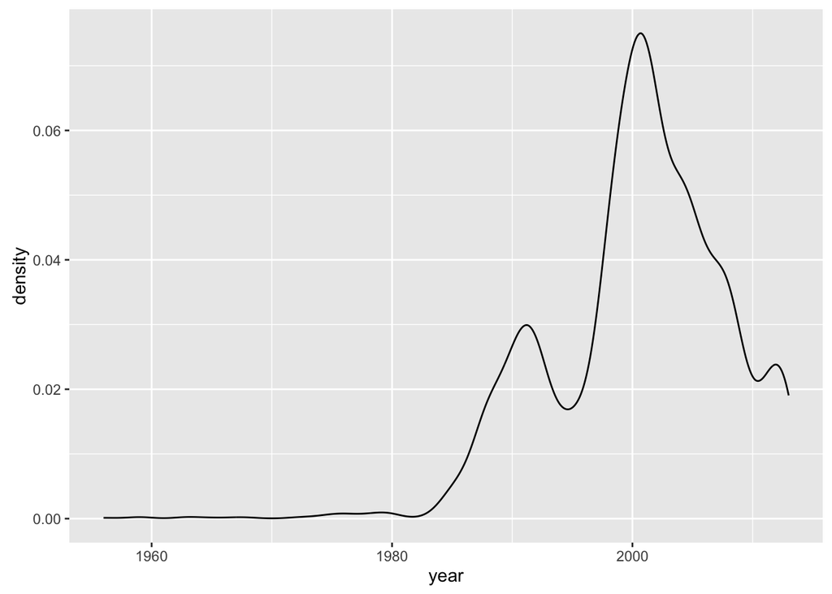

```r
ggplot(planes, aes(x=year)) +
  geom_line(stat="density")
```

+ Consider the following manufacturers: AIRBUS, AIRBUS INDUSTRIE, BOEING, BOMBARDIER INC, EMBRAER, MCDONNELL DOUGLAS, MCDONNELL DOUGLAS AIRCRAFT CO, MCDONNELL DOUGLAS CORPORATION (the most common manufacturers). Characterize and interpret the distribution of manufacturer. Has the distribution of manufacturer changed over time as reflected by the airplanes flying from NYC in 2013? [Provide a plot and a table. You probably want to combine the AIRBUS planes and the MCDONNELL DOUGLAS planes.]

```r
planes2 <- planes %>%
  filter(manufacturer %in% c("AIRBUS", "AIRBUS INDUSTRIE", "BOEING",
                             "BOMBARDIER INC", "EMBRAER", "MCDONNELL DOUGLAS",
                             "MCDONNELL DOUGLAS AIRCRAFT CO",
                             "MCDONNELL DOUGLAS CORPORATION")) %>%
  mutate(manufact2 = ifelse(substr(manufacturer,1,5)=="MCDON", "MCDONNELL DOUGLAS",
                            ifelse(substr(manufacturer,1,5) == "AIRBU", "AIRBUS",
                                   manufacturer)))  %>%
  mutate(year2 = factor(cut(year, breaks=seq(from=1960, to=2015, by=5))))

table(planes2$manufact2, planes2$year2)
```

```
##
##                     (1960,1965] (1970,1975] (1975,1980] (1980,1985]
##   AIRBUS                      0           0           0           0
##   BOEING                      1           0           0          24
##   BOMBARDIER INC              0           0           0           0
##   EMBRAER                     0           0           0           0
##   MCDONNELL DOUGLAS           0           1           7           0
##
##                     (1985,1990] (1990,1995] (1995,2000] (2000,2005]
##   AIRBUS                     13          65         212         221
##   BOEING                    150         222         444         370
##   BOMBARDIER INC              0           0          16         246
##   EMBRAER                     0           0          53         162
##   MCDONNELL DOUGLAS         118          88          19           0
##
##                     (2005,2010] (2010,2015]
##   AIRBUS                    115          92
##   BOEING                    258         134
##   BOMBARDIER INC             90          10
##   EMBRAER                    62          16
##   MCDONNELL DOUGLAS           0           0
```

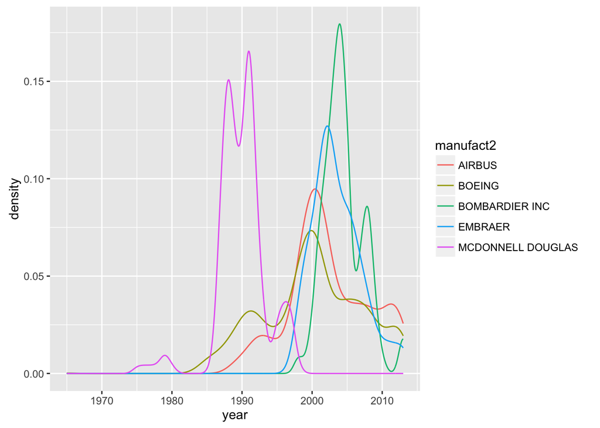

[output not shown]

```r
ggplot(planes2, aes(x=year, color=manufact2)) +
  geom_line(stat="density")
```

- Use the *nycflights13* package and the *weather* table to answer the following questions:
  - What is the distribution of temperature in July, 2013? [Provide a plot.]

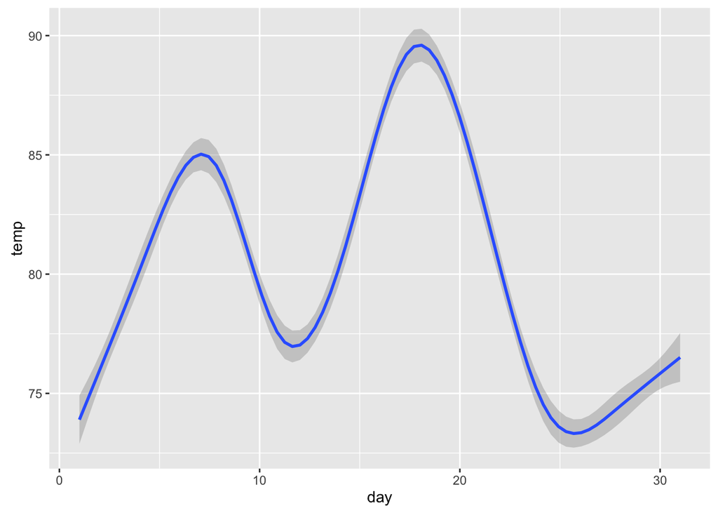

```r
data(weather)
weather2 <- weather %>% filter(month==7)
ggplot(weather2, aes(x=day, y=temp)) +
  geom_smooth()
```

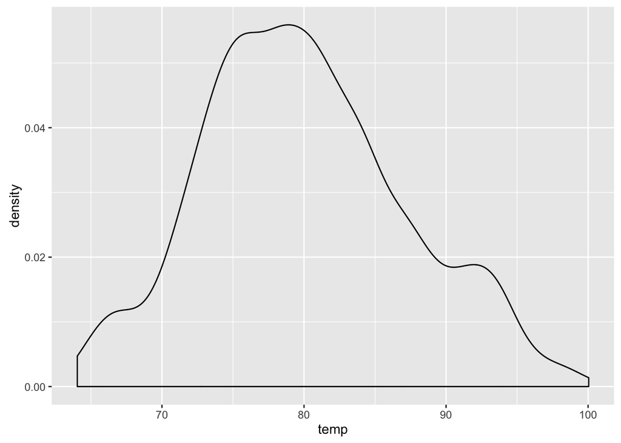

[output not shown]

```r
ggplot(weather2, aes(x=temp)) +
  geom_density()
```

```r
favstats(wind_speed, data=weather)
```

```
##  min      Q1  median       Q3      max     mean     sd     n missing
##    0 6.90468 9.20624 13.80936 1048.361 10.39587 8.5212 26127       3
```

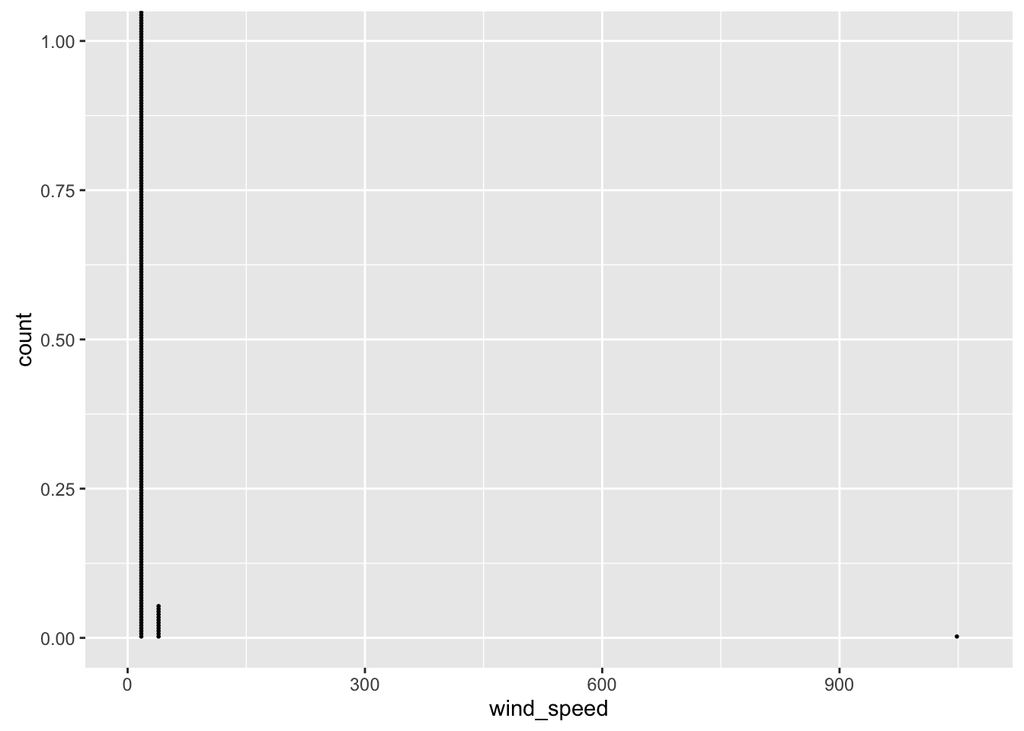

```r
ggplot(weather, aes(x=wind_speed)) +
  geom_dotplot(dotsize=.1)
```

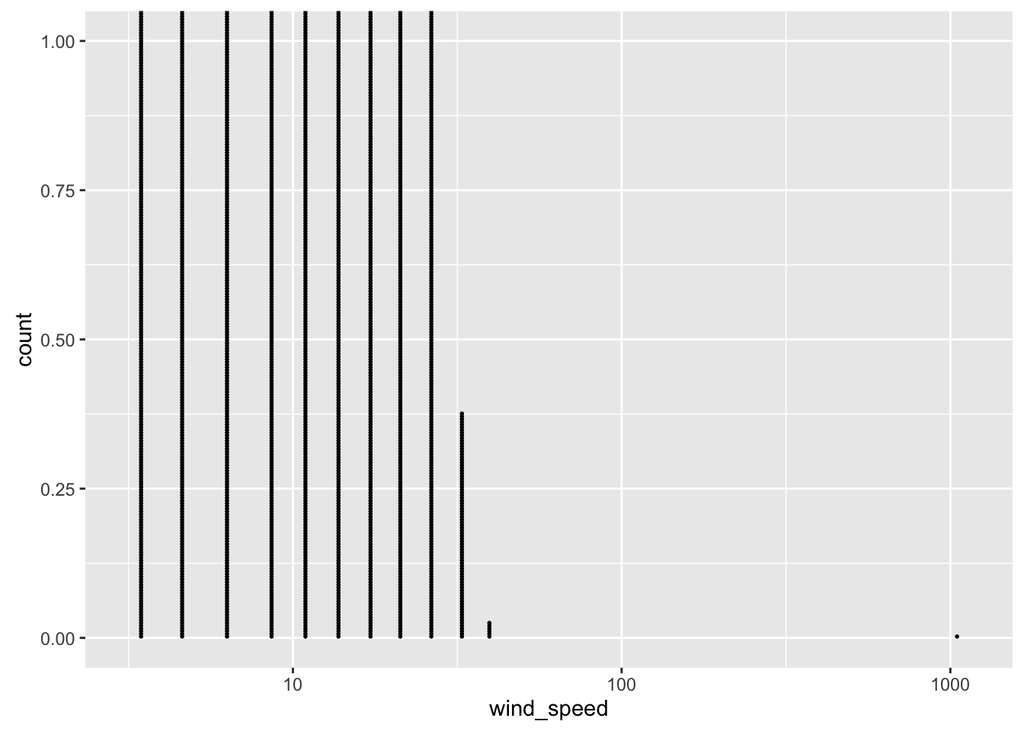

```r
ggplot(weather, aes(x=wind_speed)) +
  geom_dotplot(dotsize=.1) +
                 scale_x_log10()
```

```r
sum(weather$wind_speed > 500, na.rm=TRUE)
```

```
## [1] 1
```

```
+ What is the relationship between *dewp* and *humid*? [Provide a plot and comment.]
```

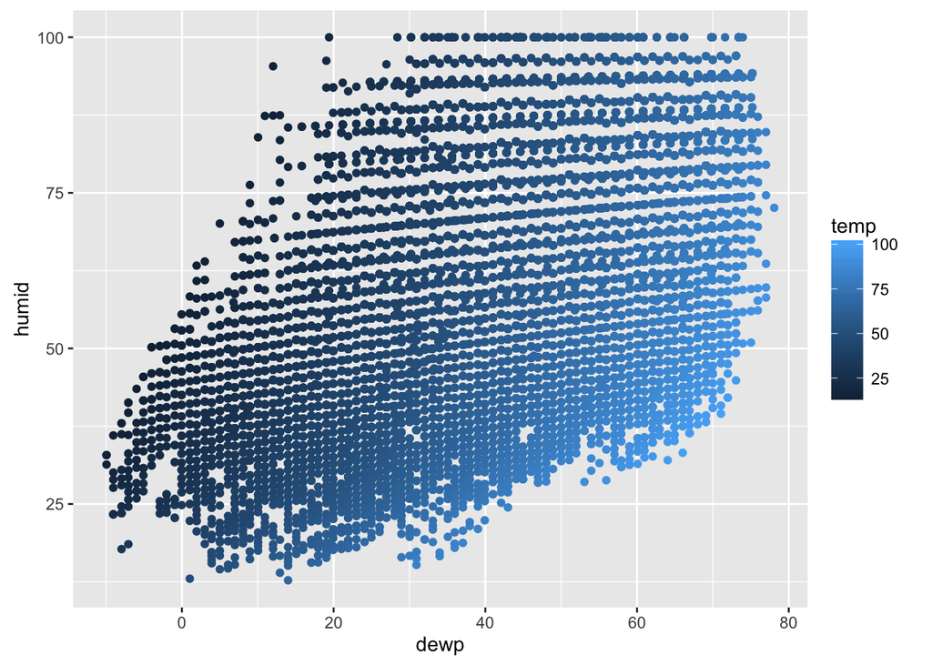

```r
ggplot(weather, aes(x=dewp, y=humid, color=temp)) +
  geom_point()
```

+ What is the relationship between *precip* and *visib*? [Provide a plot and comment.]

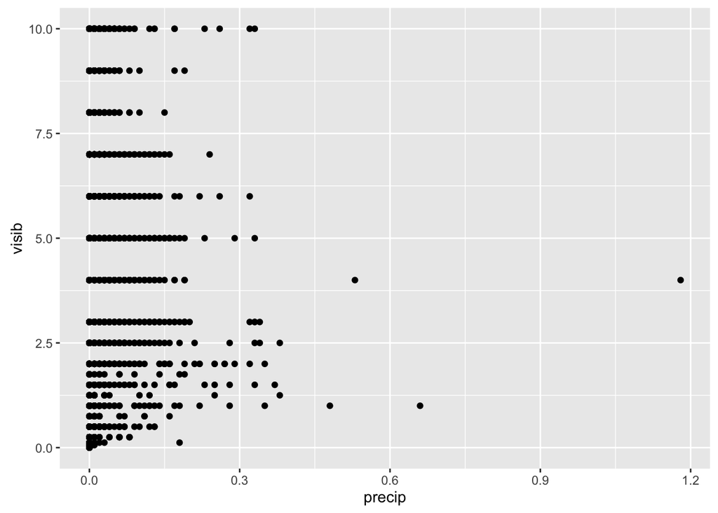

```r
ggplot(weather, aes(x=precip, y=visib)) +
  geom_point()
```

- Use the *nycflights13* package and the weather table to answer the following questions:
  - On how many days was there precipitation in the New York area in 2013?

```r
weather %>%
  group_by(month,day) %>%
  filter(precip > 0) %>%
  summarise(n()) %>%
  nrow()
```

```
## [1] 139
```

```
+ Give a graphical representation of the relationships between precipitation and arrival delay.  Comment (be careful about causation!)
```

```r
flightsweath <- inner_join(flights, weather, by=c("month", "day", "hour"))
```

[output not shown]

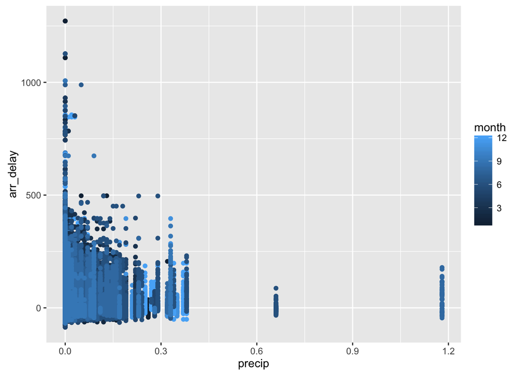

```r
ggplot(flightsweath, aes(x=precip, y=arr_delay, color=month)) +
  geom_point()
```